# NHAHES_Data_Analysis

Tanmaya Tripathi

23 April 2017

### **Libraries used**

- library(sqldf)
- library(knitr)
- library(ggplot2)
- library(corrplot)
- library(knitr)
- library(rpart)
- library(plyr)
- library(caTools)
- library(randomForest)
- library(ROCR)

### **Loading the Complete Data**

```r
complete_data <- read.csv(file = "M:/Documents/ML_Healthcare_Final_Project/NHANES_Dataset/complete_data.csv", header = TRUE, sep = ",")
```

### **Converting the dataset columns to appropriate numerics and factors**

```r
complete_data$RIDAGEYR <- as.numeric(complete_data$RIDAGEYR)
complete_data$RIDRETH1 <- as.factor(complete_data$RIDRETH1)
complete_data$DMDHHSIZ <- as.factor(complete_data$DMDHHSIZ)
complete_data$INDHHIN2 <- as.factor(complete_data$INDHHIN2)
complete_data$DMDEDUC2 <- as.factor(complete_data$DMDEDUC2)
complete_data$ALQ101 <- as.factor(complete_data$ALQ101)
complete_data$BPQ020 <- as.factor(complete_data$BPQ020)
complete_data$BPQ080 <- as.factor(complete_data$BPQ080)
complete_data$DED031 <- as.factor(complete_data$DED031)
complete_data$DEQ034A <- as.factor(complete_data$DEQ034A)
complete_data$DEQ034D <- as.factor(complete_data$DEQ034D)
complete_data$DIQ010 <- as.factor(complete_data$DIQ010)
complete_data$DIQ050 <- as.factor(complete_data$DIQ050)
complete_data$DBQ197 <- as.factor(complete_data$DBQ197)
complete_data$DBQ229 <- as.factor(complete_data$DBQ229)
complete_data$DBQ235A <- as.factor(complete_data$DBQ235A)
complete_data$DBQ235B <- as.factor(complete_data$DBQ235B)
complete_data$DBQ235C <- as.factor(complete_data$DBQ235C)
complete_data$DBD905 <- as.numeric(complete_data$DBD905)
complete_data$DBD910 <- as.numeric(complete_data$DBD910)
complete_data$DUQ217 <- as.factor(complete_data$DUQ217)
complete_data$DUQ219 <- as.factor(complete_data$DUQ219)
complete_data$HIQ011 <- as.factor(complete_data$HIQ011)
complete_data$HIQ011 <- as.factor(complete_data$HIQ011)
complete_data$HUQ010 <- as.factor(complete_data$HUQ010)
complete_data$HUQ030 <- as.factor(complete_data$HUQ030)
complete_data$HOQ065 <- as.factor(complete_data$HOQ065)
complete_data$KIQ022 <- as.factor(complete_data$KIQ022)
complete_data$KIQ026 <- as.factor(complete_data$KIQ026)
complete_data$URDFLOW1 <- as.numeric(complete_data$URDFLOW1)
complete_data$URDFLOW1_STATE <- as.factor(complete_data$URDFLOW1_STATE)
```

### **Converting Factors to Dummy Columns**

```r
complete_data_dummy_matrix <- model.matrix(~., data=complete_data)[,-1]
complete_data_dummy <- as.data.frame(complete_data_dummy_matrix)

numeric_val <- match(c("X", "SEQN", "RIDAGEYR", "DBD905", "DBD910", "URDFLOW1"), colnames(complete_data_dummy))

#str(complete_data_dummy)

for(i in 1:nrow(complete_data_dummy)){
  for(j in 1:ncol(complete_data_dummy))
  {
    if(!j %in% numeric_val)
      complete_data_dummy[i,j] <- ifelse(complete_data_dummy[i,j]==1, "Yes", "No")
  }
}

for(i in 1:ncol(complete_data_dummy)){
      # if a column is categorical
      if(!i %in% numeric_val)
        complete_data_dummy[,i] <- as.factor(complete_data_dummy[,i])
}

write.csv(complete_data_dummy, paste("M:/Documents/ML_Healthcare_Final_Project/NHANES_Dataset/complete_data_dummy.csv"))
```

### **Developing the Logistic Regression Model**

```r
log_reg_model <- glm(URDFLOW1_STATENor ~ . - URDFLOW1 - X - SEQN, data = complete_data_dummy, family = "binomial")
summary(log_reg_model)
```

```
##
## Call:
## glm(formula = URDFLOW1_STATENor ~ . - URDFLOW1 - X - SEQN, family = "binomial",
##     data = complete_data_dummy)
##
## Deviance Residuals:
##     Min       1Q   Median       3Q      Max
## -2.7042   0.2973   0.4197   0.5425   1.2168
##
## Coefficients: (1 not defined because of singularities)
##                    Estimate    Std. Error z value Pr(>|z|)
## (Intercept)     14.00904183  493.47682120   0.028  0.97735
## RIDAGEYR         0.01461528    0.01094500   1.335  0.18177
## RIDRETH12Yes     0.20241494    0.31615746   0.640  0.52202
## RIDRETH13Yes     0.45098325    0.25272521   1.784  0.07435 .
## RIDRETH14Yes    -0.44745384    0.26521805  -1.687  0.09158 .
## RIDRETH15Yes     0.43161025    0.30516768   1.414  0.15726
## DMDHHSIZ2Yes     0.07048144    0.30231185   0.233  0.81565
## DMDHHSIZ3Yes     0.08460066    0.30917129   0.274  0.78436
## DMDHHSIZ4Yes     0.41109864    0.31804589   1.293  0.19616
## DMDHHSIZ5Yes     0.04765204    0.31628094   0.151  0.88024
## DMDHHSIZ6Yes     0.17264923    0.38444537   0.449  0.65337
## DMDHHSIZ7Yes    -0.14731776    0.37569269  -0.392  0.69497
## INDHHIN22Yes    -0.66281086    0.57049667  -1.162  0.24531
## INDHHIN23Yes    -0.34158873    0.51378253  -0.665  0.50615
## INDHHIN24Yes    -0.38110471    0.52572659  -0.725  0.46851
## INDHHIN25Yes    -0.31961328    0.50631509  -0.631  0.52787
## INDHHIN26Yes     0.15492188    0.50477547   0.307  0.75891
## INDHHIN27Yes    -0.15012103    0.49814202  -0.301  0.76314
## INDHHIN28Yes    -0.11514411    0.51341192  -0.224  0.82255
## INDHHIN29Yes     0.44103072    0.59279863   0.744  0.45689
## INDHHIN210Yes   -0.30105877    0.55767124  -0.540  0.58930
## INDHHIN212Yes    0.43056130    0.59841462   0.720  0.47183
## INDHHIN213Yes    0.88518035    1.15817142   0.764  0.44469
## INDHHIN214Yes    0.99018337    0.56905347   1.740  0.08185 .
## INDHHIN215Yes   -0.36060877    0.50738847  -0.711  0.47726
## DMDEDUC22Yes     0.21308275    0.39812487   0.535  0.59250
## DMDEDUC23Yes    -0.23892400    0.38482610  -0.621  0.53469
## DMDEDUC24Yes     0.01207725    0.39233525   0.031  0.97544
## DMDEDUC25Yes     0.12126294    0.42810258   0.283  0.77698
```

[output cut: 50 more lines]

```
## HUQ0303Yes      14.67181550  815.59721895   0.018  0.98565
## HOQ0652Yes      -0.19795392    0.16695765  -1.186  0.23576
## HOQ0653Yes      -0.18852086    0.43387388  -0.435  0.66392
## KIQ0222Yes       0.67271637    0.57761347   1.165  0.24416
## KIQ0262Yes       0.23368322    0.31563597   0.740  0.45908
## ---
## Signif. codes:  0 '***' 0.001 '**' 0.01 '*' 0.05 '.' 0.1 ' ' 1
##
## (Dispersion parameter for binomial family taken to be 1)
##
##     Null deviance: 1466.8  on 1980  degrees of freedom
## Residual deviance: 1340.0  on 1898  degrees of freedom
## AIC: 1506
##
## Number of Fisher Scoring iterations: 15
```

From the above summary we can see that columns DEQ034D2, DEQ034D3, DEQ034D4 and DEQ034D5 are significant. However, one column in particular, DEQ034D4 is highly significant. The above columns have all been derived from the column DEQ034D.

The definition of the column is as follows-  
The column is a part of the Deramtology dataset in the NHANES data. The user is asked the question whether they use sunscreen or not.

```r
Code_or_Value <- c(1, 2, 3, 4, 5)
Value_Description <- c("Always", "Most of the time", "Sometimes", "Rarely", "Never")
sunscreen_code <- data.frame(Code_or_Value, Value_Description)
kable(sunscreen_code, format = 'markdown')
```

| Code_or_Value | Value_Description |
| --- | --- |
| 1 | Always |
| 2 | Most of the time |
| 3 | Sometimes |
| 4 | Rarely |
| 5 | Never |

#### **Understanding relation between Urine Flow Rate and Use of sunscreen**

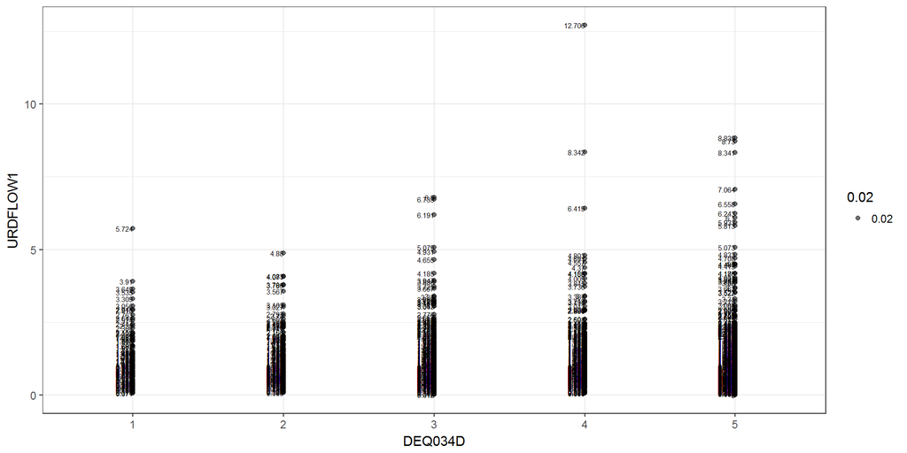

```r
ggplot(complete_data, aes(x = DEQ034D, y = URDFLOW1, label = URDFLOW1)) +
    geom_point(aes(alpha=.02)) +
    geom_text(hjust = 1, size = 2) +
    scale_size(range = c(1,15)) +
    theme_bw()
```

From the above graph we can see that there is a slight correlation. As your rate of use of sunscreen decreases the urine flow rate increases. However, the above result should be taken with a pinch of salt. As often said, Correlation is not Causation. There can be multiple reasons as to why the above correlation is occuring-  
1. The model maybe incorrect  
2. There might be another variable which correlates with the above two fields - for eg. people who go out in the sun for a majority of their time would usually end up drinking more water which leads to a more stronger urine flow.

To understand the results we need to analyze the data further.

### **Developing the Decision Tree Model**

```r
Model_Name <- character(2)
Train_Accuracy <- double(2)
Test_Accuracy <- double(2)

Model_Name[1] <- "Decision Tree"
Model_Name[2] <- "Random Forest"

set.seed(101)
complete_data_dummy$split_var <- sample.split(complete_data_dummy$URDFLOW1_STATENor, SplitRatio = .50)
complete_data_dummy_train <- subset(complete_data_dummy, split_var == TRUE)
complete_data_dummy_test <- subset(complete_data_dummy, split_var == FALSE)

decision_tree_model <- rpart(URDFLOW1_STATENor ~ . - URDFLOW1 - X - SEQN - split_var,
    method="class", data=complete_data_dummy_train)
#printcp(decision_tree_model)
summary(decision_tree_model)
```

```
## Call:
## rpart(formula = URDFLOW1_STATENor ~ . - URDFLOW1 - X - SEQN -
##     split_var, data = complete_data_dummy_train, method = "class")
##   n= 990
##
##       CP nsplit rel error   xerror       xstd
## 1 0.0125      0 1.0000000 1.000000 0.08557589
## 2 0.0100      3 0.9583333 1.058333 0.08768159
##
## Variable importance
## RIDRETH14 INDHHIN22    DBD910
##        39        33        27
##
## Node number 1: 990 observations,    complexity param=0.0125
##   predicted class=Yes  expected loss=0.1212121  P(node) =1
##     class counts:   120   870
##    probabilities: 0.121 0.879
##   left son=2 (175 obs) right son=3 (815 obs)
##   Primary splits:
##       RIDRETH14 splits as  RL, improve=4.392562, (0 missing)
##       DED0313   splits as  LR, improve=2.375870, (0 missing)
##       RIDRETH13 splits as  LR, improve=2.359877, (0 missing)
##       DUQ2193   splits as  RL, improve=2.021339, (0 missing)
##       HIQ0112   splits as  RL, improve=1.935877, (0 missing)
##
## Node number 2: 175 observations,    complexity param=0.0125
##   predicted class=Yes  expected loss=0.2228571  P(node) =0.1767677
##     class counts:    39   136
##    probabilities: 0.223 0.777
##   left son=4 (9 obs) right son=5 (166 obs)
##   Primary splits:
##       INDHHIN22 splits as  RL,       improve=3.737625, (0 missing)
##       DUQ2174   splits as  RL,       improve=3.162976, (0 missing)
##       DBQ235A2  splits as  RL,       improve=2.711454, (0 missing)
##       DBD910    < 11   to the right, improve=2.711454, (0 missing)
##       INDHHIN28 splits as  LR,       improve=1.749218, (0 missing)
##
## Node number 3: 815 observations
##   predicted class=Yes  expected loss=0.0993865  P(node) =0.8232323
##     class counts:    81   734
```

[output cut: 13 more lines]

```
##       DBD910    < 11   to the right, improve=3.053569, (0 missing)
##       DUQ2174   splits as  RL,       improve=2.774255, (0 missing)
##       DBQ235A2  splits as  RL,       improve=2.029563, (0 missing)
##       INDHHIN27 splits as  RL,       improve=1.841162, (0 missing)
##       RIDAGEYR  < 37.5 to the left,  improve=1.800422, (0 missing)
##
## Node number 10: 8 observations
##   predicted class=No   expected loss=0.375  P(node) =0.008080808
##     class counts:     5     3
##    probabilities: 0.625 0.375
##
## Node number 11: 158 observations
##   predicted class=Yes  expected loss=0.1772152  P(node) =0.159596
##     class counts:    28   130
##    probabilities: 0.177 0.823
```

```r
complete_data_dummy_train$dec_tree_pred <- predict(decision_tree_model, complete_data_dummy_train, type = 'class')
complete_data_dummy_test$dec_tree_pred <- predict(decision_tree_model, complete_data_dummy_test, type = 'class')

table(complete_data_dummy_train$dec_tree_pred, complete_data_dummy_train$URDFLOW1_STATENor)
```

```
##
##        No Yes
##   No   11   6
##   Yes 109 864
```

```r
table(complete_data_dummy_test$dec_tree_pred, complete_data_dummy_test$URDFLOW1_STATENor)
```

```
##
##        No Yes
##   No    4  16
##   Yes 117 854
```

```r
Train_Accuracy[1] <- 100*sum((complete_data_dummy_train$URDFLOW1_STATENor == "Yes" & complete_data_dummy_train$dec_tree_pred == "Yes") |
      (complete_data_dummy_train$URDFLOW1_STATENor == "No" & complete_data_dummy_train$dec_tree_pred == "No"))/nrow(complete_data_dummy_train)
Test_Accuracy[1] <- 100*sum((complete_data_dummy_test$URDFLOW1_STATENor == "Yes" & complete_data_dummy_test$dec_tree_pred == "Yes") |
      (complete_data_dummy_test$URDFLOW1_STATENor == "No" & complete_data_dummy_test$dec_tree_pred == "No"))/nrow(complete_data_dummy_test)
```

### **Developing the Random Forest Model**

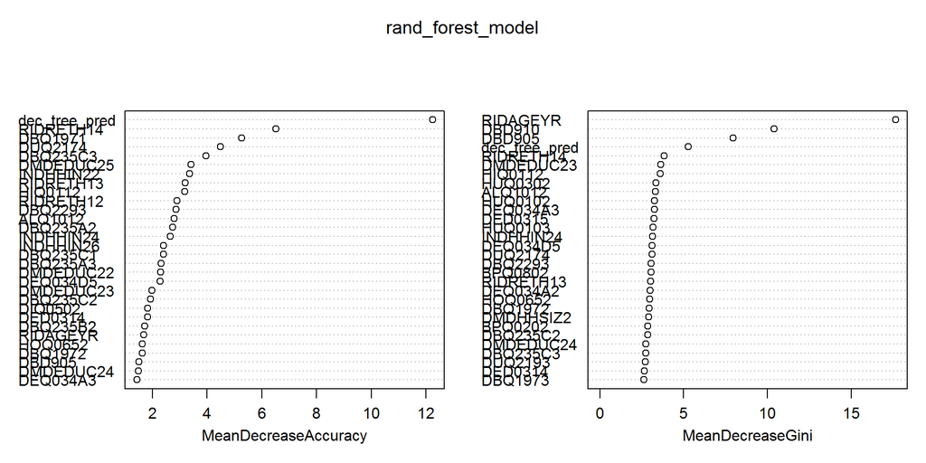

```r
rand_forest_model <- randomForest(URDFLOW1_STATENor ~ . - URDFLOW1 - X - SEQN - split_var,
                      data=complete_data_dummy_train,
                      importance=TRUE)

varImpPlot(rand_forest_model)
```

Predicting the outcomes-

```r
complete_data_dummy_train$rand_for_pred <- predict(rand_forest_model, complete_data_dummy_train, type = 'class')
complete_data_dummy_test$rand_for_pred <- predict(rand_forest_model, complete_data_dummy_test, type = 'class')

table(complete_data_dummy_train$rand_for_pred, complete_data_dummy_train$URDFLOW1_STATENor)
```

```
##
##        No Yes
##   No  120   0
##   Yes   0 870
```

```r
table(complete_data_dummy_test$rand_for_pred, complete_data_dummy_test$URDFLOW1_STATENor)
```

```
##
##        No Yes
##   No    1  10
##   Yes 120 860
```

```r
Train_Accuracy[2] <- 100*sum((complete_data_dummy_train$URDFLOW1_STATENor == "Yes" & complete_data_dummy_train$rand_for_pred == "Yes") |
      (complete_data_dummy_train$URDFLOW1_STATENor == "No" & complete_data_dummy_train$rand_for_pred == "No"))/nrow(complete_data_dummy_train)
Test_Accuracy[2] <- 100*sum((complete_data_dummy_test$URDFLOW1_STATENor == "Yes" & complete_data_dummy_test$rand_for_pred == "Yes") |
      (complete_data_dummy_test$URDFLOW1_STATENor == "No" & complete_data_dummy_test$rand_for_pred == "No"))/nrow(complete_data_dummy_test)

accuracy_data <- data.frame(Model_Name,
                            Train_Accuracy,
                            Test_Accuracy, stringsAsFactors = FALSE)

kable(accuracy_data, format = 'markdown')
```

| Model_Name | Train_Accuracy | Test_Accuracy |
| --- | --- | --- |
| Decision Tree | 88.38384 | 86.57921 |
| Random Forest | 100.00000 | 86.88194 |

As you can see from above Random Forest performed exceptionally for the training set. However, the accuracy was on par with Decision Tree for Test set. This shows that there is overfitting in the model.

### **Developing the ROC curve**

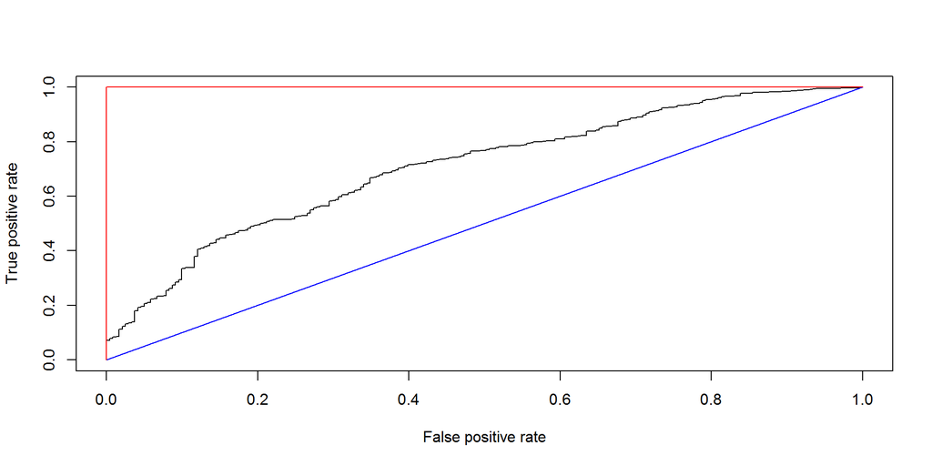

```r
roc_log_reg_pred_raw <- predict(log_reg_model, complete_data_dummy, type = 'response')

decision_tree_model <- rpart(URDFLOW1_STATENor ~ . - URDFLOW1 - X - SEQN - split_var, method="class", data=complete_data_dummy)
roc_dec_tree_pred_raw <- predict(decision_tree_model, complete_data_dummy, type = 'prob')
#complete_data_dummy$dec_tree_pred <- dec_tree_pred_raw[,2]

rand_forest_model <- randomForest(URDFLOW1_STATENor ~ . - URDFLOW1 - X - SEQN - split_var,
                      data=complete_data_dummy,
                      importance=TRUE)
roc_rand_for_pred_raw <- predict(rand_forest_model, complete_data_dummy, type = 'prob')

roc_pred_log <- prediction(roc_log_reg_pred_raw, complete_data_dummy$URDFLOW1_STATENor)
roc_pred_dec_tree <- prediction(roc_dec_tree_pred_raw[,2], complete_data_dummy$URDFLOW1_STATENor)
roc_pred_rand_for <- prediction(roc_rand_for_pred_raw[,2], complete_data_dummy$URDFLOW1_STATENor)

plot1 <- performance(roc_pred_log, measure="tpr", x.measure="fpr")
plot2 <- performance(roc_pred_dec_tree, measure="tpr", x.measure="fpr")
plot3 <- performance(roc_pred_rand_for, measure="tpr", x.measure="fpr")

plot(plot1, col="black")
plot(plot2, add = TRUE, col = "Blue")
plot(plot3, add = TRUE, col = "Red")
```

From the above model we can see that randomForest is providing 100% accuracy. However, the models were executed on the entire dataset and as we have seen earlier splitting the data into train and test decreases the accuracy. The worst performing model here is the decision tree (blue line) while Logistic Regression is in the middle of random forest and decision tree.